# Colour - Tutorial

[Colour](https://github.com/KelSolaar/Colour/) spreads over various domains of the Colour Science from colour models to optical phenomenons, this tutorial will not give you a complete overview of the API but will still be good introduction.

> Note: A directory full of examples is available at this path in your [Colour](https://github.com/KelSolaar/Colour/) installation: *colour/examples*. You can also explore it directly on Github: https://github.com/colour-science/colour/tree/master/colour/examples

```python
%matplotlib inline
```

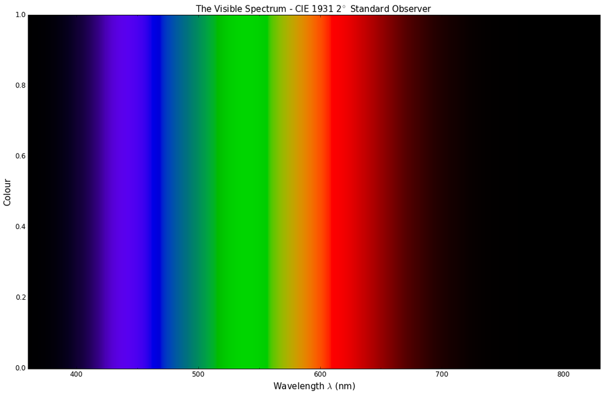

```
True
```

```python
from colour.plotting import *

visible_spectrum_plot()
```

## Overview

[Colour](https://github.com/KelSolaar/Colour/) is organised around various sub-packages:

- **adaptation**: Chromatic adaptation models and transformations.
- **algebra**: Algebra utilities.
- **appearance**: Colour appearance models.
- **characterisation**: Colour fitting and camera characterisation.
- **colorimetry**: Core objects for colour computations.
- **constants**: *CIE* and *CODATA* constants.
- **corresponding**: Corresponding colour chromaticities computations.
- **difference**: Colour difference computations.
- **examples**: Examples for the sub-packages.
- **io**: Input / output objects.
- **models**: Colour models.
- **notation**: Colour notation systems.
- **phenomenons**: Computation of various optical phenomenons.
- **plotting**: Diagrams, figures, etc...
- **quality**: Colour quality computation.
- **recovery**: Reflectance recovery.
- **temperature**: Colour temperature and correlated colour temperature computation.
- **utilities**: Various utilities and data structures.
- **volume**: Colourspace volumes computation and optimal colour stimuli.

Most of the public API is available from the root colour namespace:

```python
import colour

print(colour.__all__[:5] + ['...'])
```

```
['CHROMATIC_ADAPTATION_TRANSFORMS', 'XYZ_SCALING_CAT', 'VON_KRIES_CAT', 'BRADFORD_CAT', 'SHARP_CAT', '...']
```

The various sub-packages also expose their public API:

```python
from pprint import pprint

import colour.plotting

for sub_package in ('adaptation', 'algebra', 'appearance', 'characterisation',
                    'colorimetry', 'constants', 'corresponding', 'difference',
                    'io', 'models', 'notation', 'phenomenons', 'plotting',
                    'quality', 'recovery', 'temperature', 'utilities',
                    'volume'):
    print(sub_package.title())
    pprint(getattr(colour, sub_package).__all__)
    print('\n')
```

```
Adaptation
['CHROMATIC_ADAPTATION_TRANSFORMS',
 'XYZ_SCALING_CAT',
 'VON_KRIES_CAT',
 'BRADFORD_CAT',
 'SHARP_CAT',
 'FAIRCHILD_CAT',
 'CMCCAT97_CAT',
 'CMCCAT2000_CAT',
 'CAT02_CAT',
 'CAT02_BRILL_CAT',
 'BS_CAT',
 'BS_PC_CAT',
 'chromatic_adaptation_matrix_VonKries',
 'chromatic_adaptation_VonKries',
 'chromatic_adaptation_Fairchild1990',
 'CMCCAT2000_InductionFactors',
 'CMCCAT2000_VIEWING_CONDITIONS',
 'CMCCAT2000_forward',
 'CMCCAT2000_reverse',
 'chromatic_adaptation_CMCCAT2000',
 'chromatic_adaptation_CIE1994']


Algebra
['cartesian_to_spherical',
 'spherical_to_cartesian',
 'cartesian_to_cylindrical',
 'cylindrical_to_cartesian',
 'Extrapolator1d',
 'LinearInterpolator',
 'SpragueInterpolator',
 'CubicSplineInterpolator',
 'PchipInterpolator',
 'is_identity',
 'random_triplet_generator']


Appearance
['Hunt_InductionFactors',
```

[output cut: 405 more lines]

```
 'message_box',
 'warning']


Volume
['ILLUMINANTS_OPTIMAL_COLOUR_STIMULI',
 'is_within_macadam_limits',
 'is_within_mesh_volume',
 'is_within_pointer_gamut',
 'is_within_visible_spectrum',
 'RGB_colourspace_limits',
 'RGB_colourspace_volume_MonteCarlo',
 'RGB_colourspace_volume_coverage_MonteCarlo',
 'RGB_colourspace_pointer_gamut_coverage_MonteCarlo',
 'RGB_colourspace_visible_spectrum_coverage_MonteCarlo']
```

The code is well documented and almost every docstrings have usage examples:

```python
print(colour.CCT_to_uv_Ohno2013.__doc__)
```

```
    Returns the *CIE UCS* colourspace *uv* chromaticity coordinates from given
    correlated colour temperature :math:`T_{cp}`, :math:`\Delta_{uv}` and
    colour matching functions using Ohno (2013) method.

    Parameters
    ----------
    CCT : numeric
        Correlated colour temperature :math:`T_{cp}`.
    D_uv : numeric, optional
        :math:`\Delta_{uv}`.
    cmfs : XYZ_ColourMatchingFunctions, optional
        Standard observer colour matching functions.

    Returns
    -------
    ndarray
        *CIE UCS* colourspace *uv* chromaticity coordinates.

    References
    ----------
    .. [4]  Ohno, Y. (2014). Practical Use and Calculation of CCT and Duv.
            LEUKOS, 10(1), 47–55. doi:10.1080/15502724.2014.839020

    Examples
    --------
    >>> from colour import STANDARD_OBSERVERS_CMFS
    >>> cmfs = 'CIE 1931 2 Degree Standard Observer'
    >>> cmfs = STANDARD_OBSERVERS_CMFS.get(cmfs)
    >>> CCT = 6507.4342201047066
    >>> D_uv = 0.003223690901512735
    >>> CCT_to_uv_Ohno2013(CCT, D_uv, cmfs)  # doctest: +ELLIPSIS
    array([ 0.1978003...,  0.3122005...])
```

At the core of [Colour](https://github.com/KelSolaar/Colour/) is the *colour.colorimetry* sub-package, it defines the objects needed for spectral related computations and many others:

```python
from pprint import pprint
import colour.colorimetry as colorimetry

pprint(colorimetry.__all__)
```

```
['DEFAULT_WAVELENGTH_DECIMALS',
 'SpectralMapping',
 'SpectralShape',
 'SpectralPowerDistribution',
 'TriSpectralPowerDistribution',
 'DEFAULT_SPECTRAL_SHAPE',
 'constant_spd',
 'zeros_spd',
 'ones_spd',
 'blackbody_spd',
 'blackbody_spectral_radiance',
 'planck_law',
 'LMS_ConeFundamentals',
 'RGB_ColourMatchingFunctions',
 'XYZ_ColourMatchingFunctions',
 'CMFS',
 'LMS_CMFS',
 'RGB_CMFS',
 'STANDARD_OBSERVERS_CMFS',
 'ILLUMINANTS',
 'D_ILLUMINANTS_S_SPDS',
 'ILLUMINANTS_RELATIVE_SPDS',
 'LIGHT_SOURCES',
 'LIGHT_SOURCES_RELATIVE_SPDS',
 'LEFS',
 'PHOTOPIC_LEFS',
 'SCOTOPIC_LEFS',
 'BANDPASS_CORRECTION_METHODS',
 'bandpass_correction',
 'bandpass_correction_Stearns1988',
 'D_illuminant_relative_spd',
 'mesopic_luminous_efficiency_function',
 'mesopic_weighting_function',
 'LIGHTNESS_METHODS',
 'lightness',
 'lightness_Glasser1958',
 'lightness_Wyszecki1963',
 'lightness_1976',
 'LUMINANCE_METHODS',
 'luminance',
 'luminance_Newhall1943',
 'luminance_ASTMD153508',
 'luminance_1976',
 'luminous_flux',
 'luminous_efficacy',
 'RGB_10_degree_cmfs_to_LMS_10_degree_cmfs',
 'RGB_2_degree_cmfs_to_XYZ_2_degree_cmfs',
 'RGB_10_degree_cmfs_to_XYZ_10_degree_cmfs',
 'LMS_2_degree_cmfs_to_XYZ_2_degree_cmfs',
 'LMS_10_degree_cmfs_to_XYZ_10_degree_cmfs',
 'spectral_to_XYZ',
 'wavelength_to_XYZ',
 'WHITENESS_METHODS',
 'whiteness',
 'whiteness_Berger1959',
 'whiteness_Taube1960',
 'whiteness_Stensby1968',
 'whiteness_ASTM313',
 'whiteness_Ganz1979',
 'whiteness_CIE2004']
```

[Colour](https://github.com/KelSolaar/Colour/) computations are based on a comprehensive dataset available in pretty much each sub-packages, for example *colour.colorimetry.dataset* defines the following data:

```python
import colour.colorimetry.dataset as dataset

pprint(dataset.__all__)
```

```
['CMFS',
 'LMS_CMFS',
 'RGB_CMFS',
 'STANDARD_OBSERVERS_CMFS',
 'ILLUMINANTS',
 'D_ILLUMINANTS_S_SPDS',
 'ILLUMINANTS_RELATIVE_SPDS',
 'LIGHT_SOURCES',
 'LIGHT_SOURCES_RELATIVE_SPDS',
 'LEFS',
 'PHOTOPIC_LEFS',
 'SCOTOPIC_LEFS']
```

## Spectral Computations

### From Spectral Power Distribution

Whether it be a sample spectral power distribution, colour matching functions or illuminants, spectral data is manipulated using an object built with the *colour.SpectralPowerDistribution* class or based on it:

```python
# Defining a sample spectral power distribution data.
sample_spd_data = {
    380: 0.048,
    385: 0.051,
    390: 0.055,
    395: 0.060,
    400: 0.065,
    405: 0.068,
    410: 0.068,
    415: 0.067,
    420: 0.064,
    425: 0.062,
    430: 0.059,
    435: 0.057,
    440: 0.055,
    445: 0.054,
    450: 0.053,
    455: 0.053,
    460: 0.052,
    465: 0.052,
    470: 0.052,
    475: 0.053,
    480: 0.054,
    485: 0.055,
    490: 0.057,
    495: 0.059,
    500: 0.061,
    505: 0.062,
    510: 0.065,
    515: 0.067,
    520: 0.070,
    525: 0.072,
    530: 0.074,
    535: 0.075,
    540: 0.076,
    545: 0.078,
    550: 0.079,
    555: 0.082,
    560: 0.087,
    565: 0.092,
    570: 0.100,
    575: 0.107,
    580: 0.115,
    585: 0.122,
    590: 0.129,
    595: 0.134,
    600: 0.138,
    605: 0.142,
    610: 0.146,
    615: 0.150,
    620: 0.154,
    625: 0.158,
    630: 0.163,
    635: 0.167,
    640: 0.173,
    645: 0.180,
    650: 0.188,
    655: 0.196,
    660: 0.204,
    665: 0.213,
    670: 0.222,
    675: 0.231,
    680: 0.242,
    685: 0.251,
    690: 0.261,
    695: 0.271,
    700: 0.282,
    705: 0.294,
    710: 0.305,
    715: 0.318,
    720: 0.334,
    725: 0.354,
    730: 0.372,
    735: 0.392,
    740: 0.409,
    745: 0.420,
    750: 0.436,
    755: 0.450,
    760: 0.462,
    765: 0.465,
    770: 0.448,
    775: 0.432,
    780: 0.421}

spd = colour.SpectralPowerDistribution('Sample', sample_spd_data)
print(spd)
```

```
<colour.colorimetry.spectrum.SpectralPowerDistribution object at 0x7f62051ff5d0>
```

The sample spectral power distribution can be easily plotted against the visible spectrum:

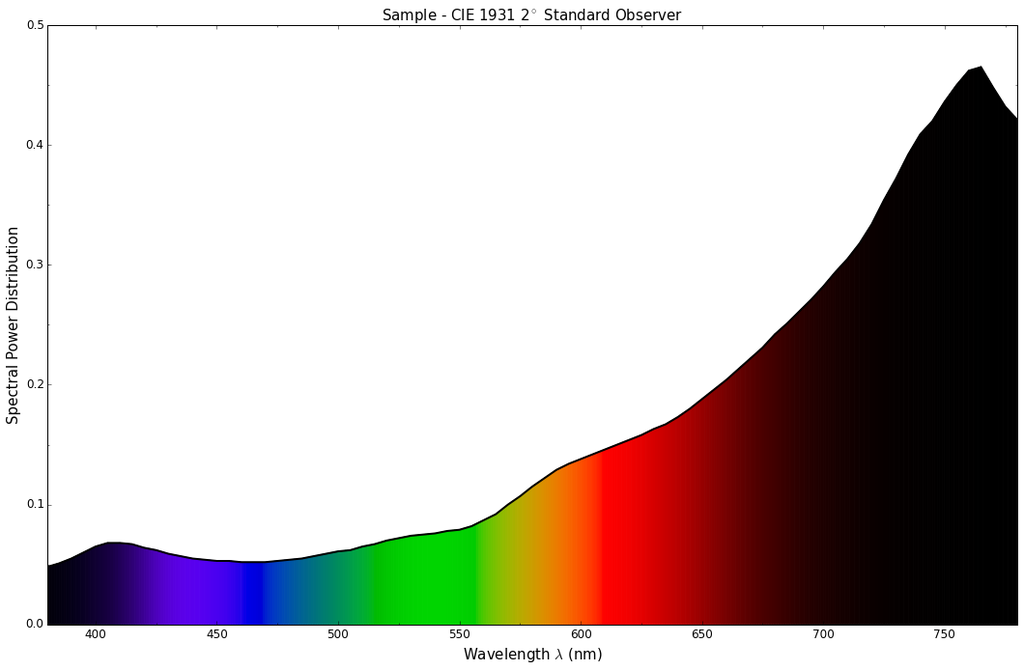

```
True
```

```python
# Plotting the sample spectral power distribution.
single_spd_plot(spd)
```

With the sample spectral power distribution defined, we can retrieve its shape:

```python
# Displaying the sample spectral power distribution shape.
print(spd.shape)
```

```
(380.0, 780.0, 5.0)
```

The shape returned is an instance of *colour.SpectralShape* class:

```python
repr(spd.shape)
```

```
'SpectralShape(380.0, 780.0, 5.0)'
```

*colour.SpectralShape* is used throughout [Colour](https://github.com/KelSolaar/Colour/) to define spectral dimensions and is instantiated as follows:

```python
# Using *colour.SpectralShape* with iteration.
shape = colour.SpectralShape(start=0, end=10, steps=1)
for wavelength in shape:
    print(wavelength)

# *colour.SpectralShape.range* method is providing the complete range of values.
shape = colour.SpectralShape(0, 10, 0.5)
shape.range()
```

```
0.0
1.0
2.0
3.0
4.0
5.0
6.0
7.0
8.0
9.0
10.0
```

```
array([  0. ,   0.5,   1. ,   1.5,   2. ,   2.5,   3. ,   3.5,   4. ,
         4.5,   5. ,   5.5,   6. ,   6.5,   7. ,   7.5,   8. ,   8.5,
         9. ,   9.5,  10. ])
```

[Colour](https://github.com/KelSolaar/Colour/) defines three convenient objects to create constant spectral power distributions:

- *colour.constant_spd*
- *colour.zeros_spd*
- *colour.ones_spd*

```python
# Defining a constant spectral power distribution.
constant_spd = colour.constant_spd(100)
print('"Constant Spectral Power Distribution"')
print(constant_spd.shape)
print(constant_spd[400])

# Defining a zeros filled spectral power distribution.
print('\n"Zeros Filled Spectral Power Distribution"')
zeros_spd = colour.zeros_spd()
print(zeros_spd.shape)
print(zeros_spd[400])

# Defining a ones filled spectral power distribution.
print('\n"Ones Filled Spectral Power Distribution"')
ones_spd = colour.ones_spd()
print(ones_spd.shape)
print(ones_spd[400])
```

```
"Constant Spectral Power Distribution"
(360.0, 830.0, 1.0)
100.0

"Zeros Filled Spectral Power Distribution"
(360.0, 830.0, 1.0)
0.0

"Ones Filled Spectral Power Distribution"
(360.0, 830.0, 1.0)
1.0
```

By default the shape used by *colour.constant_spd*, *colour.zeros_spd* and *colour.ones_spd* is the one defined by *colour.DEFAULT_SPECTRAL_SHAPE* attribute using the *CIE 1931 2° Standard Observer* shape.

```python
print(repr(colour.DEFAULT_SPECTRAL_SHAPE))
```

```
SpectralShape(360.0, 830.0, 1.0)
```

A custom shape can be passed to construct a constant spectral power distribution with tailored dimensions:

```python
colour.ones_spd(colour.SpectralShape(400, 700, 5))[450]
```

```
array(1.0)
```

The *colour.SpectralPowerDistribution* class supports the following arithmetical operations:

- *addition*
- *subtraction*
- *multiplication*
- *division*

```python
spd1 = colour.ones_spd()
print('"Ones Filled Spectral Power Distribution"')
print(spd1[400])

print('\n"x2 Constant Multiplied"')
print((spd1 * 2)[400])

print('\n"+ Spectral Power Distribution"')
print((spd1 + colour.ones_spd())[400])
```

[output not shown]

Often interpolation of the spectral power distribution is needed, this is achieved with the *colour.SpectralPowerDistribution.interpolate* method. Depending on the wavelengths uniformity, the default interpolation method will differ. Following *CIE 167:2005* recommendation: The method developed by *Sprague* (1880) should be used for interpolating functions having a uniformly spaced independent variable and a *Cubic Spline* method for non-uniformly spaced independent variable. [1]

We can check the uniformity of the sample spectral power distribution:

```python
# Checking the sample spectral power distribution uniformity.
print(spd.is_uniform())
```

```
True
```

Since the sample spectral power distribution is uniform the interpolation will be using the *colour.SpragueInterpolator* interpolator.

> Note: Interpolation happens in place and may alter your original data, use the *colour.SpectralPowerDistribution.clone* method to produce a copy of your spectral power distribution before interpolation.

```python
# Cloning the sample spectral power distribution.
clone_spd = spd.clone()

# Interpolating the cloned sample spectral power distribution.
clone_spd.interpolate(colour.SpectralShape(400, 770, 1))
clone_spd[401]
```

```
array(0.06580960000000001)
```

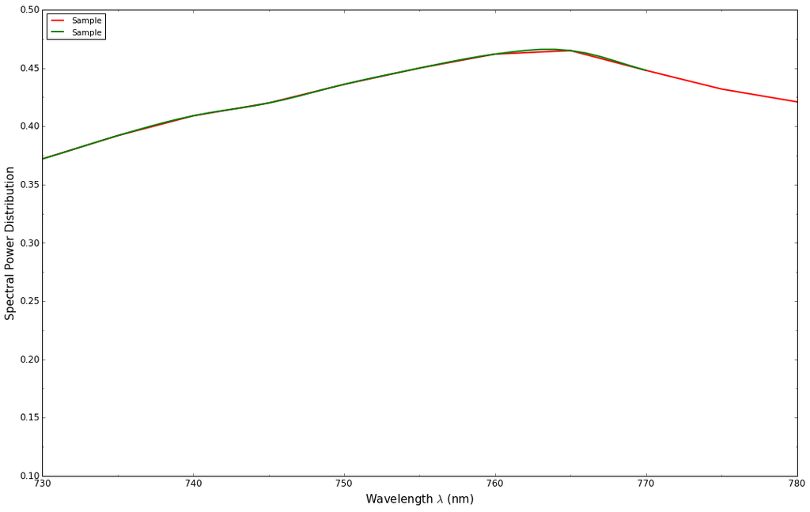

```
True
```

```python
# Comparing the interpolated spectral power distribution with the original one.
multi_spd_plot([spd, clone_spd], bounding_box=[730,780, 0.1, 0.5])
```

Extrapolation although dangerous can be used to help aligning two spectral power distributions together. *CIE publication CIE 15:2004 "Colorimetry"* recommends that unmeasured values may be set equal to the nearest measured value of the appropriate quantity in truncation: [2]

```python
# Extrapolating the cloned sample spectral power distribution.
clone_spd.extrapolate(colour.SpectralShape(340, 830))
clone_spd[340], clone_spd[830]
```

```
(array(0.065), array(0.448))
```

The extrapolation can be forced to use *Linear* method instead of the *Constant* default method or even use arbitrary constant *left* and *right* values:

```python
# Extrapolating the cloned sample spectral power distribution with *Linear* method.
# We first trim the spectral power distribution using the interpolation method,
# the steps being the same, no interpolation will actually occur.
clone_spd.interpolate(colour.SpectralShape(400, 700))
clone_spd.extrapolate(colour.SpectralShape(340, 830), method='Linear', right=0)
clone_spd[340], clone_spd[830]
```

```
(array(0.01642399999999955), array(0.0))
```

Aligning a spectral power distribution is a convenient way to first interpolatesthe current data within its original bounds then if needed extrapolates any missing values to match the requested shape:

```python
# Aligning the cloned sample spectral power distribution.
# We first trim the spectral power distribution as above.
clone_spd.interpolate(colour.SpectralShape(400, 700))
clone_spd.align(colour.SpectralShape(340, 830, 5))
clone_spd[340], clone_spd[830]
```

```
(array(0.065), array(0.282))
```

The *colour.SpectralPowerDistribution* class also supports various arithmetic operations like *addition*, *subtraction*, *multiplication* or *division* with *numeric* and *array_like* variables or other *colour.SpectralPowerDistribution* class instances:

```python
spd = colour.SpectralPowerDistribution('Sample', {410: 0.50, 420: 0.75, 430: 1., 440: 0.75, 450: 0.50})
print((spd.clone() + 1).values)
print((spd.clone() * 2).values)
print((spd * [0.35, 1.55, 0.75, 2.55, 0.95]).values)
print((spd * colour.constant_spd(2, spd.shape) * colour.constant_spd(3, spd.shape)).values)
```

```
[ 1.5   1.75  2.    1.75  1.5 ]
[ 1.   1.5  2.   1.5  1. ]
[ 0.175   1.1625  0.75    1.9125  0.475 ]
[  1.05    6.975   4.5    11.475   2.85 ]
```

The spectral power distribution can be normalised with an arbitrary factor:

```python
print(spd.normalise().values)
print(spd.normalise(100).values)
```

```
[ 0.09150327  0.60784314  0.39215686  1.          0.24836601]
[   9.1503268    60.78431373   39.21568627  100.           24.83660131]
```

### To Tristimulus Values

From a given spectral power distribution, *CIE XYZ* tristimulus values can be calculated:

```python
spd = colour.SpectralPowerDistribution('Sample', sample_spd_data)
cmfs = colour.STANDARD_OBSERVERS_CMFS['CIE 1931 2 Degree Standard Observer']
illuminant = colour.ILLUMINANTS_RELATIVE_SPDS['D65']

# Calculating the sample spectral power distribution *CIE XYZ* tristimulus values.
XYZ = colour.spectral_to_XYZ(spd, cmfs, illuminant)
print(XYZ)
```

```
[ 10.9706809    9.7027807    6.05480757]
```

> Note: Output *CIE XYZ* colourspace matrix is in domain [0, 100].

### From *CIE XYZ* Colourspace

*CIE XYZ* is the central colourspace for Colour Science from which many computations are available, cascading to even more computations:

```python
# Displaying objects interacting directly with the *CIE XYZ* colourspace.
pprint([name for name in colour.__all__ if name.startswith('XYZ_to')])
```

```
['XYZ_to_Hunt',
 'XYZ_to_ATD95',
 'XYZ_to_CIECAM02',
 'XYZ_to_LLAB',
 'XYZ_to_Nayatani95',
 'XYZ_to_RLAB',
 'XYZ_to_xyY',
 'XYZ_to_xy',
 'XYZ_to_Lab',
 'XYZ_to_Luv',
 'XYZ_to_UCS',
 'XYZ_to_UVW',
 'XYZ_to_IPT',
 'XYZ_to_RGB',
 'XYZ_to_sRGB']
```

### To Screen Colours

We can for instance converts the *CIE XYZ* tristimulus values into *sRGB* colourspace *RGB* values in order to display them on screen:

```python
# The output domain of *colour.spectral_to_XYZ* is [0, 100] and the input domain of *colour.XYZ_to_sRGB* is [0, 1].
# We need to take it in account and rescale the input *CIE XYZ* colourspace matrix.
RGB = colour.XYZ_to_sRGB(XYZ / 100)
print(RGB)
```

```
[ 0.45678515  0.30983401  0.24860046]
```

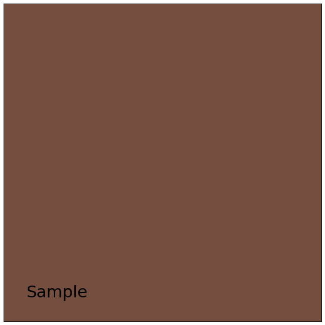

```
True
```

```python
# Plotting the *sRGB* colourspace colour of the *Sample* spectral power distribution.
single_colour_plot(colour_parameter('Sample', RGB), text_size=32)
```

### To Colour Rendition Charts

In the same way, we can compute values from a colour rendition chart sample.

> Note: This is useful for render time checks in the VFX industry, where you can use a synthetic colour chart into your render and ensure the colour management is acting as expected.

The *colour.characterisation* sub-package contains the dataset for various colour rendition charts:

```python
# Colour rendition charts chromaticity coordinates.
print(sorted(colour.characterisation.COLOURCHECKERS.keys()))

# Colour rendition charts spectral power distributions.
print(sorted(colour.characterisation.COLOURCHECKERS_SPDS.keys()))
```

```
[u'BabelColor Average', u'ColorChecker 1976', u'ColorChecker 2005', u'babel_average', u'cc2005']
[u'BabelColor Average', u'ColorChecker N Ohta', u'babel_average', u'cc_ohta']
```

> Note: The above *cc2005*, *babel_average* and *cc_ohta* keys are convenient aliases for respectively *ColorChecker 2005*, *BabelColor Average* and *ColorChecker N Ohta* keys.

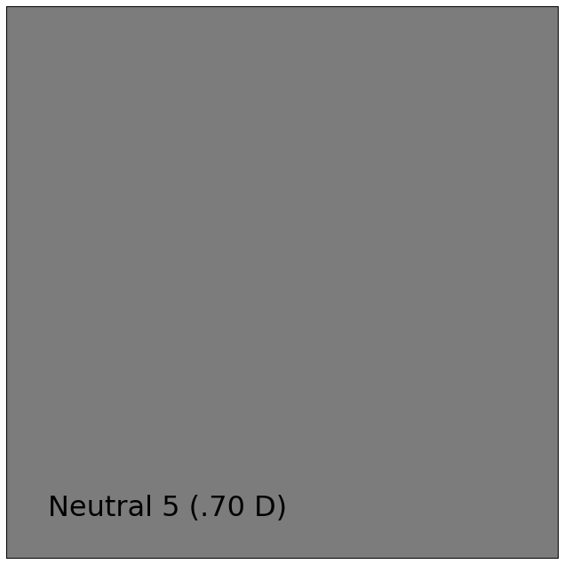

```
True
```

```python
# Plotting the *sRGB* colourspace colour of *neutral 5 (.70 D)* patch.
patch_name = 'neutral 5 (.70 D)'
patch_spd = colour.COLOURCHECKERS_SPDS['ColorChecker N Ohta'][patch_name]
XYZ = colour.spectral_to_XYZ(patch_spd, cmfs, illuminant)
RGB = colour.XYZ_to_sRGB(XYZ / 100)

single_colour_plot(colour_parameter(patch_name.title(), RGB), text_size=32)
```

[Colour](https://github.com/KelSolaar/Colour/) defines a convenient plotting object to draw synthetic colour rendition charts figures:

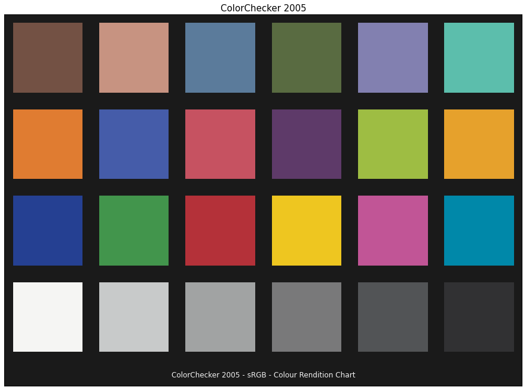

```
True
```

```python
colour_checker_plot(colour_checker='ColorChecker 2005', text_display=False)
```

### To Chromaticity Coordinates

Given a spectral power distribution, chromaticity coordinates *xy* can be computed using the *colour.XYZ_to_xy* definition:

```python
# Computing *xy* chromaticity coordinates for the *neutral 5 (.70 D)* patch.
xy =  colour.XYZ_to_xy(XYZ)
print(xy)
```

```
[ 0.31260313  0.32871262]
```

Chromaticity coordinates *xy* can be plotted into the *CIE 1931 Chromaticity Diagram*:

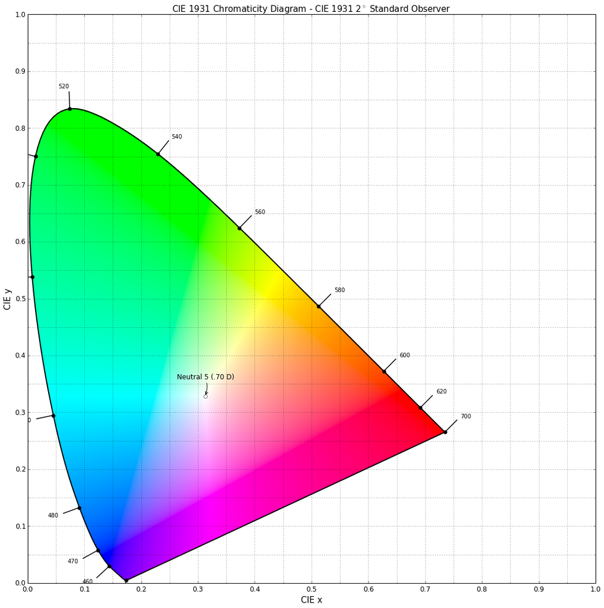

```
True
```

```python
import pylab

# Plotting the *CIE 1931 Chromaticity Diagram*.
# The argument *standalone=False* is passed so that the plot doesn't get displayed
# and can be used as a basis for other plots.
CIE_1931_chromaticity_diagram_plot(standalone=False)

# Plotting the *xy* chromaticity coordinates.
x, y = xy
pylab.plot(x, y, 'o-', color='white')

# Annotating the plot.
pylab.annotate(patch_spd.name.title(),
               xy=xy,
               xytext=(-50, 30),
               textcoords='offset points',
               arrowprops=dict(arrowstyle='->', connectionstyle='arc3, rad=-0.2'))

# Displaying the plot.
display(standalone=True)
```

### To More

We hope that this small introduction has been useful and gave you the envy to see more, if you want to explore the API a good place to start is the [IPython Notebooks](http://nbviewer.ipython.org/github/colour-science/colour-ipython/blob/master/notebooks/colour.ipynb) page.

## References

1. ^ CIE TC 1-38. (2005). 9. INTERPOLATION. In CIE 167:2005 Recommended Practice for Tabulating Spectral Data for Use in Colour Computations (pp. 14–19). ISBN:978-3-901-90641-1
2. ^ CIE TC 1-48. (2004). CIE 015:2004 Colorimetry, 3rd Edition. CIE 015:2004 Colorimetry, 3rd Edition (pp. 1–82). ISBN:978-3-901-90633-6